# Risk Factor Analysis

## Outcome Variable

**Outcome Variable:** stunted

## Predictor Variables

**Intervention Variable:** meducyrs

**Adjustment Set:**

unadjusted

## Stratifying Variables

The analysis was stratified on these variable(s):

- agecat
- studyid
- country

## Data Summary

| agecat | studyid | country | A | n | nA | nAY0 | nAY1 |
| --- | --- | --- | --- | --- | --- | --- | --- |
| Birth | ki0047075b-MAL-ED | BANGLADESH | Q4 | 207 | 59 | 55 | 4 |
| Birth | ki0047075b-MAL-ED | BANGLADESH | Q1 | 207 | 40 | 28 | 12 |
| Birth | ki0047075b-MAL-ED | BANGLADESH | Q2 | 207 | 28 | 23 | 5 |
| Birth | ki0047075b-MAL-ED | BANGLADESH | Q3 | 207 | 80 | 65 | 15 |
| Birth | ki0047075b-MAL-ED | BRAZIL | Q4 | 190 | 65 | 58 | 7 |
| Birth | ki0047075b-MAL-ED | BRAZIL | Q1 | 190 | 40 | 37 | 3 |
| Birth | ki0047075b-MAL-ED | BRAZIL | Q2 | 190 | 36 | 29 | 7 |
| Birth | ki0047075b-MAL-ED | BRAZIL | Q3 | 190 | 49 | 45 | 4 |
| Birth | ki0047075b-MAL-ED | INDIA | Q4 | 183 | 51 | 42 | 9 |
| Birth | ki0047075b-MAL-ED | INDIA | Q1 | 183 | 27 | 24 | 3 |
| Birth | ki0047075b-MAL-ED | INDIA | Q2 | 183 | 43 | 38 | 5 |
| Birth | ki0047075b-MAL-ED | INDIA | Q3 | 183 | 62 | 52 | 10 |
| Birth | ki0047075b-MAL-ED | NEPAL | Q4 | 160 | 13 | 10 | 3 |
| Birth | ki0047075b-MAL-ED | NEPAL | Q1 | 160 | 21 | 19 | 2 |
| Birth | ki0047075b-MAL-ED | NEPAL | Q2 | 160 | 47 | 41 | 6 |
| Birth | ki0047075b-MAL-ED | NEPAL | Q3 | 160 | 79 | 73 | 6 |
| Birth | ki0047075b-MAL-ED | PERU | Q4 | 286 | 87 | 77 | 10 |
| Birth | ki0047075b-MAL-ED | PERU | Q1 | 286 | 60 | 52 | 8 |
| Birth | ki0047075b-MAL-ED | PERU | Q2 | 286 | 67 | 60 | 7 |
| Birth | ki0047075b-MAL-ED | PERU | Q3 | 286 | 72 | 63 | 9 |
| Birth | ki0047075b-MAL-ED | SOUTH AFRICA | Q4 | 262 | 72 | 63 | 9 |
| Birth | ki0047075b-MAL-ED | SOUTH AFRICA | Q1 | 262 | 51 | 49 | 2 |
| Birth | ki0047075b-MAL-ED | SOUTH AFRICA | Q2 | 262 | 82 | 75 | 7 |
| Birth | ki0047075b-MAL-ED | SOUTH AFRICA | Q3 | 262 | 57 | 47 | 10 |
| Birth | ki0047075b-MAL-ED | TANZANIA, UNITED REPUBLIC OF | Q4 | 107 | 2 | 2 | 0 |
| Birth | ki0047075b-MAL-ED | TANZANIA, UNITED REPUBLIC OF | Q1 | 107 | 15 | 14 | 1 |
| Birth | ki0047075b-MAL-ED | TANZANIA, UNITED REPUBLIC OF | Q2 | 107 | 20 | 18 | 2 |
| Birth | ki0047075b-MAL-ED | TANZANIA, UNITED REPUBLIC OF | Q3 | 107 | 70 | 58 | 12 |
| Birth | ki1000108-CMC-V-BCS-2002 | INDIA | Q4 | 90 | 7 | 7 | 0 |
| Birth | ki1000108-CMC-V-BCS-2002 | INDIA | Q1 | 90 | 15 | 13 | 2 |

[output cut: 538 more lines]

The following strata were considered:

- agecat: 12 months, studyid: ki0047075b-MAL-ED, country: BANGLADESH
- agecat: 12 months, studyid: ki0047075b-MAL-ED, country: BRAZIL
- agecat: 12 months, studyid: ki0047075b-MAL-ED, country: INDIA
- agecat: 12 months, studyid: ki0047075b-MAL-ED, country: NEPAL
- agecat: 12 months, studyid: ki0047075b-MAL-ED, country: PERU
- agecat: 12 months, studyid: ki0047075b-MAL-ED, country: SOUTH AFRICA
- agecat: 12 months, studyid: ki0047075b-MAL-ED, country: TANZANIA, UNITED REPUBLIC OF
- agecat: 12 months, studyid: ki1000108-CMC-V-BCS-2002, country: INDIA
- agecat: 12 months, studyid: ki1000108-IRC, country: INDIA
- agecat: 12 months, studyid: ki1000109-EE, country: PAKISTAN
- agecat: 12 months, studyid: ki1000304b-SAS-FoodSuppl, country: INDIA
- agecat: 12 months, studyid: ki1017093-NIH-Birth, country: BANGLADESH
- agecat: 12 months, studyid: ki1017093b-PROVIDE, country: BANGLADESH
- agecat: 12 months, studyid: ki1017093c-NIH-Crypto, country: BANGLADESH
- agecat: 12 months, studyid: ki1066203-TanzaniaChild2, country: TANZANIA, UNITED REPUBLIC OF
- agecat: 12 months, studyid: ki1112895-Guatemala BSC, country: GUATEMALA
- agecat: 12 months, studyid: ki1113344-GMS-Nepal, country: NEPAL
- agecat: 12 months, studyid: ki1126311-ZVITAMBO, country: ZIMBABWE
- agecat: 12 months, studyid: ki1135781-COHORTS, country: GUATEMALA
- agecat: 12 months, studyid: ki1135781-COHORTS, country: INDIA
- agecat: 12 months, studyid: ki1135781-COHORTS, country: PHILIPPINES
- agecat: 12 months, studyid: ki1148112-LCNI-5, country: MALAWI
- agecat: 18 months, studyid: ki0047075b-MAL-ED, country: BANGLADESH
- agecat: 18 months, studyid: ki0047075b-MAL-ED, country: BRAZIL
- agecat: 18 months, studyid: ki0047075b-MAL-ED, country: INDIA
- agecat: 18 months, studyid: ki0047075b-MAL-ED, country: NEPAL
- agecat: 18 months, studyid: ki0047075b-MAL-ED, country: PERU
- agecat: 18 months, studyid: ki0047075b-MAL-ED, country: SOUTH AFRICA
- agecat: 18 months, studyid: ki0047075b-MAL-ED, country: TANZANIA, UNITED REPUBLIC OF
- agecat: 18 months, studyid: ki1000108-CMC-V-BCS-2002, country: INDIA
- agecat: 18 months, studyid: ki1000108-IRC, country: INDIA
- agecat: 18 months, studyid: ki1000109-EE, country: PAKISTAN
- agecat: 18 months, studyid: ki1000304b-SAS-FoodSuppl, country: INDIA
- agecat: 18 months, studyid: ki1017093-NIH-Birth, country: BANGLADESH
- agecat: 18 months, studyid: ki1017093b-PROVIDE, country: BANGLADESH
- agecat: 18 months, studyid: ki1017093c-NIH-Crypto, country: BANGLADESH
- agecat: 18 months, studyid: ki1066203-TanzaniaChild2, country: TANZANIA, UNITED REPUBLIC OF
- agecat: 18 months, studyid: ki1113344-GMS-Nepal, country: NEPAL
- agecat: 18 months, studyid: ki1126311-ZVITAMBO, country: ZIMBABWE
- agecat: 18 months, studyid: ki1135781-COHORTS, country: GUATEMALA
- agecat: 18 months, studyid: ki1135781-COHORTS, country: PHILIPPINES
- agecat: 18 months, studyid: ki1148112-LCNI-5, country: MALAWI
- agecat: 24 months, studyid: ki0047075b-MAL-ED, country: BANGLADESH
- agecat: 24 months, studyid: ki0047075b-MAL-ED, country: BRAZIL
- agecat: 24 months, studyid: ki0047075b-MAL-ED, country: INDIA
- agecat: 24 months, studyid: ki0047075b-MAL-ED, country: NEPAL
- agecat: 24 months, studyid: ki0047075b-MAL-ED, country: PERU
- agecat: 24 months, studyid: ki0047075b-MAL-ED, country: SOUTH AFRICA
- agecat: 24 months, studyid: ki0047075b-MAL-ED, country: TANZANIA, UNITED REPUBLIC OF
- agecat: 24 months, studyid: ki1000108-CMC-V-BCS-2002, country: INDIA
- agecat: 24 months, studyid: ki1000108-IRC, country: INDIA
- agecat: 24 months, studyid: ki1017093-NIH-Birth, country: BANGLADESH
- agecat: 24 months, studyid: ki1017093b-PROVIDE, country: BANGLADESH
- agecat: 24 months, studyid: ki1017093c-NIH-Crypto, country: BANGLADESH
- agecat: 24 months, studyid: ki1066203-TanzaniaChild2, country: TANZANIA, UNITED REPUBLIC OF
- agecat: 24 months, studyid: ki1113344-GMS-Nepal, country: NEPAL
- agecat: 24 months, studyid: ki1126311-ZVITAMBO, country: ZIMBABWE
- agecat: 24 months, studyid: ki1135781-COHORTS, country: GUATEMALA
- agecat: 24 months, studyid: ki1135781-COHORTS, country: INDIA
- agecat: 24 months, studyid: ki1135781-COHORTS, country: PHILIPPINES
- agecat: 24 months, studyid: ki1148112-LCNI-5, country: MALAWI
- agecat: 3 months, studyid: ki0047075b-MAL-ED, country: BANGLADESH
- agecat: 3 months, studyid: ki0047075b-MAL-ED, country: BRAZIL
- agecat: 3 months, studyid: ki0047075b-MAL-ED, country: INDIA
- agecat: 3 months, studyid: ki0047075b-MAL-ED, country: NEPAL
- agecat: 3 months, studyid: ki0047075b-MAL-ED, country: PERU
- agecat: 3 months, studyid: ki0047075b-MAL-ED, country: SOUTH AFRICA
- agecat: 3 months, studyid: ki0047075b-MAL-ED, country: TANZANIA, UNITED REPUBLIC OF
- agecat: 3 months, studyid: ki1000108-CMC-V-BCS-2002, country: INDIA
- agecat: 3 months, studyid: ki1000108-IRC, country: INDIA
- agecat: 3 months, studyid: ki1000109-EE, country: PAKISTAN
- agecat: 3 months, studyid: ki1000304b-SAS-FoodSuppl, country: INDIA
- agecat: 3 months, studyid: ki1017093-NIH-Birth, country: BANGLADESH
- agecat: 3 months, studyid: ki1017093b-PROVIDE, country: BANGLADESH
- agecat: 3 months, studyid: ki1017093c-NIH-Crypto, country: BANGLADESH
- agecat: 3 months, studyid: ki1066203-TanzaniaChild2, country: TANZANIA, UNITED REPUBLIC OF
- agecat: 3 months, studyid: ki1112895-Guatemala BSC, country: GUATEMALA
- agecat: 3 months, studyid: ki1113344-GMS-Nepal, country: NEPAL
- agecat: 3 months, studyid: ki1126311-ZVITAMBO, country: ZIMBABWE
- agecat: 3 months, studyid: ki1135781-COHORTS, country: GUATEMALA
- agecat: 3 months, studyid: ki1135781-COHORTS, country: INDIA
- agecat: 3 months, studyid: ki1135781-COHORTS, country: PHILIPPINES
- agecat: 6 months, studyid: ki0047075b-MAL-ED, country: BANGLADESH
- agecat: 6 months, studyid: ki0047075b-MAL-ED, country: BRAZIL
- agecat: 6 months, studyid: ki0047075b-MAL-ED, country: INDIA
- agecat: 6 months, studyid: ki0047075b-MAL-ED, country: NEPAL
- agecat: 6 months, studyid: ki0047075b-MAL-ED, country: PERU
- agecat: 6 months, studyid: ki0047075b-MAL-ED, country: SOUTH AFRICA
- agecat: 6 months, studyid: ki0047075b-MAL-ED, country: TANZANIA, UNITED REPUBLIC OF
- agecat: 6 months, studyid: ki1000108-CMC-V-BCS-2002, country: INDIA
- agecat: 6 months, studyid: ki1000108-IRC, country: INDIA
- agecat: 6 months, studyid: ki1000109-EE, country: PAKISTAN
- agecat: 6 months, studyid: ki1000304b-SAS-FoodSuppl, country: INDIA
- agecat: 6 months, studyid: ki1017093-NIH-Birth, country: BANGLADESH
- agecat: 6 months, studyid: ki1017093b-PROVIDE, country: BANGLADESH
- agecat: 6 months, studyid: ki1017093c-NIH-Crypto, country: BANGLADESH
- agecat: 6 months, studyid: ki1066203-TanzaniaChild2, country: TANZANIA, UNITED REPUBLIC OF
- agecat: 6 months, studyid: ki1112895-Guatemala BSC, country: GUATEMALA
- agecat: 6 months, studyid: ki1113344-GMS-Nepal, country: NEPAL
- agecat: 6 months, studyid: ki1126311-ZVITAMBO, country: ZIMBABWE
- agecat: 6 months, studyid: ki1135781-COHORTS, country: GUATEMALA
- agecat: 6 months, studyid: ki1135781-COHORTS, country: INDIA
- agecat: 6 months, studyid: ki1135781-COHORTS, country: PHILIPPINES
- agecat: 6 months, studyid: ki1148112-LCNI-5, country: MALAWI
- agecat: 9 months, studyid: ki0047075b-MAL-ED, country: BANGLADESH
- agecat: 9 months, studyid: ki0047075b-MAL-ED, country: BRAZIL
- agecat: 9 months, studyid: ki0047075b-MAL-ED, country: INDIA
- agecat: 9 months, studyid: ki0047075b-MAL-ED, country: NEPAL
- agecat: 9 months, studyid: ki0047075b-MAL-ED, country: PERU
- agecat: 9 months, studyid: ki0047075b-MAL-ED, country: SOUTH AFRICA
- agecat: 9 months, studyid: ki0047075b-MAL-ED, country: TANZANIA, UNITED REPUBLIC OF
- agecat: 9 months, studyid: ki1000108-CMC-V-BCS-2002, country: INDIA
- agecat: 9 months, studyid: ki1000108-IRC, country: INDIA
- agecat: 9 months, studyid: ki1000109-EE, country: PAKISTAN
- agecat: 9 months, studyid: ki1000304b-SAS-FoodSuppl, country: INDIA
- agecat: 9 months, studyid: ki1017093-NIH-Birth, country: BANGLADESH
- agecat: 9 months, studyid: ki1017093b-PROVIDE, country: BANGLADESH
- agecat: 9 months, studyid: ki1017093c-NIH-Crypto, country: BANGLADESH
- agecat: 9 months, studyid: ki1066203-TanzaniaChild2, country: TANZANIA, UNITED REPUBLIC OF
- agecat: 9 months, studyid: ki1112895-Guatemala BSC, country: GUATEMALA
- agecat: 9 months, studyid: ki1113344-GMS-Nepal, country: NEPAL
- agecat: 9 months, studyid: ki1126311-ZVITAMBO, country: ZIMBABWE
- agecat: 9 months, studyid: ki1135781-COHORTS, country: GUATEMALA
- agecat: 9 months, studyid: ki1135781-COHORTS, country: INDIA
- agecat: 9 months, studyid: ki1135781-COHORTS, country: PHILIPPINES
- agecat: 9 months, studyid: ki1148112-LCNI-5, country: MALAWI
- agecat: Birth, studyid: ki0047075b-MAL-ED, country: BANGLADESH
- agecat: Birth, studyid: ki0047075b-MAL-ED, country: BRAZIL
- agecat: Birth, studyid: ki0047075b-MAL-ED, country: INDIA
- agecat: Birth, studyid: ki0047075b-MAL-ED, country: NEPAL
- agecat: Birth, studyid: ki0047075b-MAL-ED, country: PERU
- agecat: Birth, studyid: ki0047075b-MAL-ED, country: SOUTH AFRICA
- agecat: Birth, studyid: ki0047075b-MAL-ED, country: TANZANIA, UNITED REPUBLIC OF
- agecat: Birth, studyid: ki1000108-CMC-V-BCS-2002, country: INDIA
- agecat: Birth, studyid: ki1000108-IRC, country: INDIA
- agecat: Birth, studyid: ki1000109-EE, country: PAKISTAN
- agecat: Birth, studyid: ki1017093-NIH-Birth, country: BANGLADESH
- agecat: Birth, studyid: ki1017093c-NIH-Crypto, country: BANGLADESH
- agecat: Birth, studyid: ki1126311-ZVITAMBO, country: ZIMBABWE
- agecat: Birth, studyid: ki1135781-COHORTS, country: GUATEMALA
- agecat: Birth, studyid: ki1135781-COHORTS, country: INDIA
- agecat: Birth, studyid: ki1135781-COHORTS, country: PHILIPPINES

### Dropped Strata

Some strata were dropped due to rare outcomes:

- agecat: Birth, studyid: ki0047075b-MAL-ED, country: BANGLADESH
- agecat: Birth, studyid: ki0047075b-MAL-ED, country: BRAZIL
- agecat: Birth, studyid: ki0047075b-MAL-ED, country: INDIA
- agecat: Birth, studyid: ki0047075b-MAL-ED, country: NEPAL
- agecat: Birth, studyid: ki0047075b-MAL-ED, country: SOUTH AFRICA
- agecat: Birth, studyid: ki0047075b-MAL-ED, country: TANZANIA, UNITED REPUBLIC OF
- agecat: Birth, studyid: ki1000108-CMC-V-BCS-2002, country: INDIA
- agecat: Birth, studyid: ki1000108-IRC, country: INDIA
- agecat: Birth, studyid: ki1000109-EE, country: PAKISTAN
- agecat: Birth, studyid: ki1017093-NIH-Birth, country: BANGLADESH
- agecat: Birth, studyid: ki1017093c-NIH-Crypto, country: BANGLADESH
- agecat: Birth, studyid: ki1135781-COHORTS, country: GUATEMALA
- agecat: 3 months, studyid: ki0047075b-MAL-ED, country: BANGLADESH
- agecat: 3 months, studyid: ki0047075b-MAL-ED, country: BRAZIL
- agecat: 3 months, studyid: ki0047075b-MAL-ED, country: INDIA
- agecat: 3 months, studyid: ki0047075b-MAL-ED, country: NEPAL
- agecat: 3 months, studyid: ki0047075b-MAL-ED, country: TANZANIA, UNITED REPUBLIC OF
- agecat: 3 months, studyid: ki1000108-CMC-V-BCS-2002, country: INDIA
- agecat: 3 months, studyid: ki1000108-IRC, country: INDIA
- agecat: 3 months, studyid: ki1000109-EE, country: PAKISTAN
- agecat: 3 months, studyid: ki1000304b-SAS-FoodSuppl, country: INDIA
- agecat: 3 months, studyid: ki1017093b-PROVIDE, country: BANGLADESH
- agecat: 3 months, studyid: ki1066203-TanzaniaChild2, country: TANZANIA, UNITED REPUBLIC OF
- agecat: 3 months, studyid: ki1112895-Guatemala BSC, country: GUATEMALA
- agecat: 3 months, studyid: ki1113344-GMS-Nepal, country: NEPAL
- agecat: 3 months, studyid: ki1135781-COHORTS, country: GUATEMALA
- agecat: 6 months, studyid: ki0047075b-MAL-ED, country: BANGLADESH
- agecat: 6 months, studyid: ki0047075b-MAL-ED, country: BRAZIL
- agecat: 6 months, studyid: ki0047075b-MAL-ED, country: NEPAL
- agecat: 6 months, studyid: ki0047075b-MAL-ED, country: TANZANIA, UNITED REPUBLIC OF
- agecat: 6 months, studyid: ki1000108-IRC, country: INDIA
- agecat: 6 months, studyid: ki1000109-EE, country: PAKISTAN
- agecat: 6 months, studyid: ki1000304b-SAS-FoodSuppl, country: INDIA
- agecat: 6 months, studyid: ki1017093b-PROVIDE, country: BANGLADESH
- agecat: 6 months, studyid: ki1066203-TanzaniaChild2, country: TANZANIA, UNITED REPUBLIC OF
- agecat: 6 months, studyid: ki1135781-COHORTS, country: GUATEMALA
- agecat: 6 months, studyid: ki1148112-LCNI-5, country: MALAWI
- agecat: 9 months, studyid: ki0047075b-MAL-ED, country: BANGLADESH
- agecat: 9 months, studyid: ki0047075b-MAL-ED, country: BRAZIL
- agecat: 9 months, studyid: ki0047075b-MAL-ED, country: INDIA
- agecat: 9 months, studyid: ki0047075b-MAL-ED, country: NEPAL
- agecat: 9 months, studyid: ki0047075b-MAL-ED, country: TANZANIA, UNITED REPUBLIC OF
- agecat: 9 months, studyid: ki1000108-IRC, country: INDIA
- agecat: 9 months, studyid: ki1000109-EE, country: PAKISTAN
- agecat: 9 months, studyid: ki1000304b-SAS-FoodSuppl, country: INDIA
- agecat: 9 months, studyid: ki1017093b-PROVIDE, country: BANGLADESH
- agecat: 9 months, studyid: ki1066203-TanzaniaChild2, country: TANZANIA, UNITED REPUBLIC OF
- agecat: 9 months, studyid: ki1135781-COHORTS, country: GUATEMALA
- agecat: 9 months, studyid: ki1148112-LCNI-5, country: MALAWI
- agecat: 12 months, studyid: ki0047075b-MAL-ED, country: BRAZIL
- agecat: 12 months, studyid: ki0047075b-MAL-ED, country: NEPAL
- agecat: 12 months, studyid: ki0047075b-MAL-ED, country: TANZANIA, UNITED REPUBLIC OF
- agecat: 12 months, studyid: ki1000108-IRC, country: INDIA
- agecat: 12 months, studyid: ki1000109-EE, country: PAKISTAN
- agecat: 12 months, studyid: ki1000304b-SAS-FoodSuppl, country: INDIA
- agecat: 12 months, studyid: ki1017093b-PROVIDE, country: BANGLADESH
- agecat: 12 months, studyid: ki1066203-TanzaniaChild2, country: TANZANIA, UNITED REPUBLIC OF
- agecat: 12 months, studyid: ki1135781-COHORTS, country: GUATEMALA
- agecat: 12 months, studyid: ki1148112-LCNI-5, country: MALAWI
- agecat: 18 months, studyid: ki0047075b-MAL-ED, country: BRAZIL
- agecat: 18 months, studyid: ki0047075b-MAL-ED, country: NEPAL
- agecat: 18 months, studyid: ki0047075b-MAL-ED, country: TANZANIA, UNITED REPUBLIC OF
- agecat: 18 months, studyid: ki1000108-IRC, country: INDIA
- agecat: 18 months, studyid: ki1000109-EE, country: PAKISTAN
- agecat: 18 months, studyid: ki1000304b-SAS-FoodSuppl, country: INDIA
- agecat: 18 months, studyid: ki1017093b-PROVIDE, country: BANGLADESH
- agecat: 18 months, studyid: ki1066203-TanzaniaChild2, country: TANZANIA, UNITED REPUBLIC OF
- agecat: 18 months, studyid: ki1135781-COHORTS, country: GUATEMALA
- agecat: 18 months, studyid: ki1148112-LCNI-5, country: MALAWI
- agecat: 24 months, studyid: ki0047075b-MAL-ED, country: BRAZIL
- agecat: 24 months, studyid: ki0047075b-MAL-ED, country: NEPAL
- agecat: 24 months, studyid: ki0047075b-MAL-ED, country: TANZANIA, UNITED REPUBLIC OF
- agecat: 24 months, studyid: ki1000108-IRC, country: INDIA
- agecat: 24 months, studyid: ki1017093b-PROVIDE, country: BANGLADESH
- agecat: 24 months, studyid: ki1066203-TanzaniaChild2, country: TANZANIA, UNITED REPUBLIC OF
- agecat: 24 months, studyid: ki1126311-ZVITAMBO, country: ZIMBABWE
- agecat: 24 months, studyid: ki1135781-COHORTS, country: GUATEMALA
- agecat: 24 months, studyid: ki1148112-LCNI-5, country: MALAWI

## Methods Detail

We’re interested in the causal parameters $E[Y_a]$ for all values of $a \in \mathcal{A}$. These parameters represent the mean outcome if, possibly contrary to fact, we intervened to set all units to have $A=a$. Under the randomization and positivity assumptions, these are identified by the statistical parameters $\psi_a=E_W[E_{Y|A,W}(Y|A=a,W)]$. In addition, we’re interested in the mean of $Y$, $E[Y]$ under no intervention (the observed mean). We will estimate these parameters by using SuperLearner to fit the relevant likelihood factors – $E_{Y|A,W}(Y|A=a,W)$ and $p(A=a|W)$, and then updating our likelihood fit using a joint TMLE.

For unadjusted analyses ($W=\{\}$), initial likelihoods were estimated using Lrnr_glm to estimate the simple $E(Y|A)$ and Lrnr_mean to estimate $p(A)$. For adjusted analyses, a small library containing Lrnr_glmnet, Lrnr_xgboost, and Lrnr_mean was used.

Having estimated these parameters, we will then use the delta method to estimate relative risks and attributable risks relative to a prespecified baseline level of $A$.

# Results Detail

## Results Plots

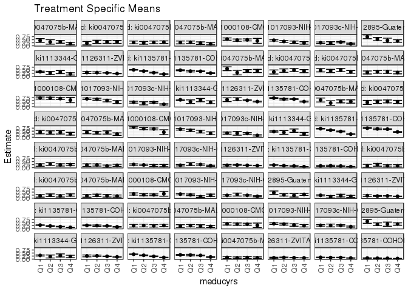

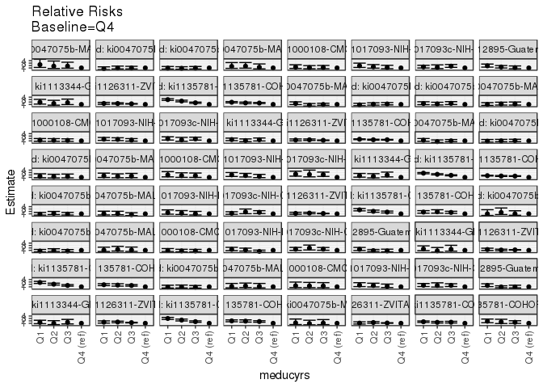

[figure not shown]

[figure not shown]

## Results Table

### Parameter: TSM

| agecat | studyid | country | intervention_level | baseline_level | estimate | ci_lower | ci_upper |
| --- | --- | --- | --- | --- | --- | --- | --- |
| Birth | ki0047075b-MAL-ED | PERU | Q4 | NA | 0.1149425 | 0.0478035 | 0.1820816 |
| Birth | ki0047075b-MAL-ED | PERU | Q1 | NA | 0.1333333 | 0.0471688 | 0.2194979 |
| Birth | ki0047075b-MAL-ED | PERU | Q2 | NA | 0.1044776 | 0.0311072 | 0.1778481 |
| Birth | ki0047075b-MAL-ED | PERU | Q3 | NA | 0.1250000 | 0.0484753 | 0.2015247 |
| Birth | ki1126311-ZVITAMBO | ZIMBABWE | Q4 | NA | 0.0986547 | 0.0923874 | 0.1049221 |
| Birth | ki1126311-ZVITAMBO | ZIMBABWE | Q1 | NA | 0.1057692 | 0.0639730 | 0.1475654 |
| Birth | ki1126311-ZVITAMBO | ZIMBABWE | Q2 | NA | 0.1309524 | 0.0986884 | 0.1632163 |
| Birth | ki1126311-ZVITAMBO | ZIMBABWE | Q3 | NA | 0.1108138 | 0.1016268 | 0.1200009 |
| Birth | ki1135781-COHORTS | INDIA | Q4 | NA | 0.0875995 | 0.0743828 | 0.1008163 |
| Birth | ki1135781-COHORTS | INDIA | Q1 | NA | 0.1429385 | 0.1265663 | 0.1593107 |
| Birth | ki1135781-COHORTS | INDIA | Q2 | NA | 0.1228669 | 0.1011626 | 0.1445712 |
| Birth | ki1135781-COHORTS | INDIA | Q3 | NA | 0.1263670 | 0.1036646 | 0.1490693 |
| Birth | ki1135781-COHORTS | PHILIPPINES | Q4 | NA | 0.0439443 | 0.0307899 | 0.0570987 |
| Birth | ki1135781-COHORTS | PHILIPPINES | Q1 | NA | 0.0815047 | 0.0602704 | 0.1027390 |
| Birth | ki1135781-COHORTS | PHILIPPINES | Q2 | NA | 0.0687023 | 0.0380687 | 0.0993359 |
| Birth | ki1135781-COHORTS | PHILIPPINES | Q3 | NA | 0.0624486 | 0.0488520 | 0.0760453 |
| 3 months | ki0047075b-MAL-ED | PERU | Q4 | NA | 0.2528736 | 0.1613807 | 0.3443664 |
| 3 months | ki0047075b-MAL-ED | PERU | Q1 | NA | 0.2222222 | 0.1193852 | 0.3250592 |
| 3 months | ki0047075b-MAL-ED | PERU | Q2 | NA | 0.3030303 | 0.1919656 | 0.4140950 |
| 3 months | ki0047075b-MAL-ED | PERU | Q3 | NA | 0.2297297 | 0.1337206 | 0.3257388 |
| 3 months | ki0047075b-MAL-ED | SOUTH AFRICA | Q4 | NA | 0.1951220 | 0.1091942 | 0.2810497 |
| 3 months | ki0047075b-MAL-ED | SOUTH AFRICA | Q1 | NA | 0.2105263 | 0.1045017 | 0.3165510 |
| 3 months | ki0047075b-MAL-ED | SOUTH AFRICA | Q2 | NA | 0.2222222 | 0.1315235 | 0.3129210 |
| 3 months | ki0047075b-MAL-ED | SOUTH AFRICA | Q3 | NA | 0.1311475 | 0.0462861 | 0.2160090 |
| 3 months | ki1017093-NIH-Birth | BANGLADESH | Q4 | NA | 0.1739130 | 0.0844005 | 0.2634256 |
| 3 months | ki1017093-NIH-Birth | BANGLADESH | Q1 | NA | 0.2627119 | 0.2065124 | 0.3189113 |
| 3 months | ki1017093-NIH-Birth | BANGLADESH | Q2 | NA | 0.2280702 | 0.1651262 | 0.2910142 |
| 3 months | ki1017093-NIH-Birth | BANGLADESH | Q3 | NA | 0.1808511 | 0.1029744 | 0.2587277 |
| 3 months | ki1017093c-NIH-Crypto | BANGLADESH | Q4 | NA | 0.1604938 | 0.1143106 | 0.2066771 |
| 3 months | ki1017093c-NIH-Crypto | BANGLADESH | Q1 | NA | 0.2000000 | 0.1415250 | 0.2584750 |

[output cut: 226 more lines]

### Parameter: E(Y)

| agecat | studyid | country | intervention_level | baseline_level | estimate | ci_lower | ci_upper |
| --- | --- | --- | --- | --- | --- | --- | --- |
| Birth | ki0047075b-MAL-ED | PERU | NA | NA | 0.1188811 | 0.1176826 | 0.1200796 |
| Birth | ki1126311-ZVITAMBO | ZIMBABWE | NA | NA | 0.1036930 | 0.1035692 | 0.1038168 |
| Birth | ki1135781-COHORTS | INDIA | NA | NA | 0.1182899 | 0.1176616 | 0.1189181 |
| Birth | ki1135781-COHORTS | PHILIPPINES | NA | NA | 0.0613115 | 0.0608316 | 0.0617913 |
| 3 months | ki0047075b-MAL-ED | PERU | NA | NA | 0.2517241 | 0.2482424 | 0.2552059 |
| 3 months | ki0047075b-MAL-ED | SOUTH AFRICA | NA | NA | 0.1921708 | 0.1882168 | 0.1961249 |
| 3 months | ki1017093-NIH-Birth | BANGLADESH | NA | NA | 0.2280702 | 0.2252007 | 0.2309396 |
| 3 months | ki1017093c-NIH-Crypto | BANGLADESH | NA | NA | 0.2142857 | 0.2109046 | 0.2176668 |
| 3 months | ki1126311-ZVITAMBO | ZIMBABWE | NA | NA | 0.1783613 | 0.1780578 | 0.1786648 |
| 3 months | ki1135781-COHORTS | INDIA | NA | NA | 0.1513728 | 0.1498788 | 0.1528669 |
| 3 months | ki1135781-COHORTS | PHILIPPINES | NA | NA | 0.1234783 | 0.1224953 | 0.1244612 |
| 6 months | ki0047075b-MAL-ED | INDIA | NA | NA | 0.1730769 | 0.1679480 | 0.1782058 |
| 6 months | ki0047075b-MAL-ED | PERU | NA | NA | 0.2205882 | 0.2166124 | 0.2245641 |
| 6 months | ki0047075b-MAL-ED | SOUTH AFRICA | NA | NA | 0.1968504 | 0.1938741 | 0.1998267 |
| 6 months | ki1000108-CMC-V-BCS-2002 | INDIA | NA | NA | 0.3008130 | 0.2973922 | 0.3042338 |
| 6 months | ki1017093-NIH-Birth | BANGLADESH | NA | NA | 0.2681564 | 0.2621770 | 0.2741359 |
| 6 months | ki1017093c-NIH-Crypto | BANGLADESH | NA | NA | 0.2097902 | 0.2066308 | 0.2129496 |
| 6 months | ki1112895-Guatemala BSC | GUATEMALA | NA | NA | 0.3104693 | 0.3029571 | 0.3179815 |
| 6 months | ki1113344-GMS-Nepal | NEPAL | NA | NA | 0.2125000 | 0.2093592 | 0.2156408 |
| 6 months | ki1126311-ZVITAMBO | ZIMBABWE | NA | NA | 0.1665057 | 0.1661824 | 0.1668289 |
| 6 months | ki1135781-COHORTS | INDIA | NA | NA | 0.1915758 | 0.1894988 | 0.1936528 |
| 6 months | ki1135781-COHORTS | PHILIPPINES | NA | NA | 0.2112260 | 0.2094510 | 0.2130010 |
| 9 months | ki0047075b-MAL-ED | PERU | NA | NA | 0.2470588 | 0.2453284 | 0.2487893 |
| 9 months | ki0047075b-MAL-ED | SOUTH AFRICA | NA | NA | 0.2120000 | 0.2090802 | 0.2149198 |
| 9 months | ki1000108-CMC-V-BCS-2002 | INDIA | NA | NA | 0.3688525 | 0.3661254 | 0.3715795 |
| 9 months | ki1017093-NIH-Birth | BANGLADESH | NA | NA | 0.3570020 | 0.3517650 | 0.3622389 |
| 9 months | ki1017093c-NIH-Crypto | BANGLADESH | NA | NA | 0.2322946 | 0.2287639 | 0.2358254 |
| 9 months | ki1112895-Guatemala BSC | GUATEMALA | NA | NA | 0.4051724 | 0.3944812 | 0.4158636 |
| 9 months | ki1113344-GMS-Nepal | NEPAL | NA | NA | 0.2823315 | 0.2795556 | 0.2851074 |
| 9 months | ki1126311-ZVITAMBO | ZIMBABWE | NA | NA | 0.1982252 | 0.1975945 | 0.1988559 |
| 9 months | ki1135781-COHORTS | INDIA | NA | NA | 0.2647555 | 0.2615656 | 0.2679453 |
| 9 months | ki1135781-COHORTS | PHILIPPINES | NA | NA | 0.2750737 | 0.2724991 | 0.2776484 |
| 12 months | ki0047075b-MAL-ED | BANGLADESH | NA | NA | 0.3068783 | 0.2942552 | 0.3195015 |
| 12 months | ki0047075b-MAL-ED | INDIA | NA | NA | 0.3050000 | 0.2997491 | 0.3102509 |
| 12 months | ki0047075b-MAL-ED | PERU | NA | NA | 0.2816327 | 0.2793432 | 0.2839221 |
| 12 months | ki0047075b-MAL-ED | SOUTH AFRICA | NA | NA | 0.2380952 | 0.2318011 | 0.2443894 |
| 12 months | ki1000108-CMC-V-BCS-2002 | INDIA | NA | NA | 0.4972826 | 0.4929824 | 0.5015828 |
| 12 months | ki1017093-NIH-Birth | BANGLADESH | NA | NA | 0.3747454 | 0.3676279 | 0.3818630 |
| 12 months | ki1017093c-NIH-Crypto | BANGLADESH | NA | NA | 0.2422096 | 0.2382101 | 0.2462092 |
| 12 months | ki1112895-Guatemala BSC | GUATEMALA | NA | NA | 0.5000000 | 0.4830263 | 0.5169737 |
| 12 months | ki1113344-GMS-Nepal | NEPAL | NA | NA | 0.3441441 | 0.3391882 | 0.3491001 |
| 12 months | ki1126311-ZVITAMBO | ZIMBABWE | NA | NA | 0.2445862 | 0.2438719 | 0.2453005 |
| 12 months | ki1135781-COHORTS | INDIA | NA | NA | 0.3515166 | 0.3470016 | 0.3560315 |
| 12 months | ki1135781-COHORTS | PHILIPPINES | NA | NA | 0.3868472 | 0.3834689 | 0.3902254 |
| 18 months | ki0047075b-MAL-ED | BANGLADESH | NA | NA | 0.4611111 | 0.4474531 | 0.4747691 |
| 18 months | ki0047075b-MAL-ED | INDIA | NA | NA | 0.4550000 | 0.4474187 | 0.4625813 |
| 18 months | ki0047075b-MAL-ED | PERU | NA | NA | 0.4479638 | 0.4394901 | 0.4564375 |
| 18 months | ki0047075b-MAL-ED | SOUTH AFRICA | NA | NA | 0.3402490 | 0.3365471 | 0.3439509 |
| 18 months | ki1000108-CMC-V-BCS-2002 | INDIA | NA | NA | 0.6883469 | 0.6845016 | 0.6921922 |
| 18 months | ki1017093-NIH-Birth | BANGLADESH | NA | NA | 0.5874730 | 0.5789548 | 0.5959912 |
| 18 months | ki1017093c-NIH-Crypto | BANGLADESH | NA | NA | 0.3012618 | 0.2950811 | 0.3074426 |
| 18 months | ki1113344-GMS-Nepal | NEPAL | NA | NA | 0.5338208 | 0.5276891 | 0.5399526 |
| 18 months | ki1126311-ZVITAMBO | ZIMBABWE | NA | NA | 0.4754098 | 0.4725883 | 0.4782314 |
| 18 months | ki1135781-COHORTS | PHILIPPINES | NA | NA | 0.5874799 | 0.5831043 | 0.5918556 |
| 24 months | ki0047075b-MAL-ED | BANGLADESH | NA | NA | 0.4444444 | 0.4335100 | 0.4553789 |
| 24 months | ki0047075b-MAL-ED | INDIA | NA | NA | 0.4070352 | 0.4032541 | 0.4108163 |
| 24 months | ki0047075b-MAL-ED | PERU | NA | NA | 0.3700000 | 0.3624619 | 0.3775381 |
| 24 months | ki0047075b-MAL-ED | SOUTH AFRICA | NA | NA | 0.3529412 | 0.3448136 | 0.3610687 |
| 24 months | ki1000108-CMC-V-BCS-2002 | INDIA | NA | NA | 0.7150538 | 0.7051087 | 0.7249988 |
| 24 months | ki1017093-NIH-Birth | BANGLADESH | NA | NA | 0.5547786 | 0.5439120 | 0.5656451 |
| 24 months | ki1017093c-NIH-Crypto | BANGLADESH | NA | NA | 0.2568093 | 0.2494200 | 0.2641987 |
| 24 months | ki1113344-GMS-Nepal | NEPAL | NA | NA | 0.4495968 | 0.4434174 | 0.4557761 |
| 24 months | ki1135781-COHORTS | INDIA | NA | NA | 0.4815520 | 0.4758994 | 0.4872046 |
| 24 months | ki1135781-COHORTS | PHILIPPINES | NA | NA | 0.6167689 | 0.6119301 | 0.6216077 |

### Parameter: RR

| agecat | studyid | country | intervention_level | baseline_level | estimate | ci_lower | ci_upper |
| --- | --- | --- | --- | --- | --- | --- | --- |
| Birth | ki0047075b-MAL-ED | PERU | Q4 | Q4 | 1.0000000 | 1.0000000 | 1.000000 |
| Birth | ki0047075b-MAL-ED | PERU | Q1 | Q4 | 1.1600000 | 0.4854531 | 2.771844 |
| Birth | ki0047075b-MAL-ED | PERU | Q2 | Q4 | 0.9089552 | 0.3646239 | 2.265895 |
| Birth | ki0047075b-MAL-ED | PERU | Q3 | Q4 | 1.0875000 | 0.4666067 | 2.534589 |
| Birth | ki1126311-ZVITAMBO | ZIMBABWE | Q4 | Q4 | 1.0000000 | 1.0000000 | 1.000000 |
| Birth | ki1126311-ZVITAMBO | ZIMBABWE | Q1 | Q4 | 1.0721154 | 0.7184895 | 1.599789 |
| Birth | ki1126311-ZVITAMBO | ZIMBABWE | Q2 | Q4 | 1.3273809 | 1.0291878 | 1.711971 |
| Birth | ki1126311-ZVITAMBO | ZIMBABWE | Q3 | Q4 | 1.1232492 | 1.0118486 | 1.246915 |
| Birth | ki1135781-COHORTS | INDIA | Q4 | Q4 | 1.0000000 | 1.0000000 | 1.000000 |
| Birth | ki1135781-COHORTS | INDIA | Q1 | Q4 | 1.6317265 | 1.3501420 | 1.972038 |
| Birth | ki1135781-COHORTS | INDIA | Q2 | Q4 | 1.4025974 | 1.1118380 | 1.769394 |
| Birth | ki1135781-COHORTS | INDIA | Q3 | Q4 | 1.4425526 | 1.1408908 | 1.823976 |
| Birth | ki1135781-COHORTS | PHILIPPINES | Q4 | Q4 | 1.0000000 | 1.0000000 | 1.000000 |
| Birth | ki1135781-COHORTS | PHILIPPINES | Q1 | Q4 | 1.8547289 | 1.2471976 | 2.758199 |
| Birth | ki1135781-COHORTS | PHILIPPINES | Q2 | Q4 | 1.5633960 | 0.9137570 | 2.674898 |
| Birth | ki1135781-COHORTS | PHILIPPINES | Q3 | Q4 | 1.4210874 | 0.9814470 | 2.057665 |
| 3 months | ki0047075b-MAL-ED | PERU | Q4 | Q4 | 1.0000000 | 1.0000000 | 1.000000 |
| 3 months | ki0047075b-MAL-ED | PERU | Q1 | Q4 | 0.8787879 | 0.4883949 | 1.581237 |
| 3 months | ki0047075b-MAL-ED | PERU | Q2 | Q4 | 1.1983471 | 0.7160022 | 2.005630 |
| 3 months | ki0047075b-MAL-ED | PERU | Q3 | Q4 | 0.9084767 | 0.5226896 | 1.579006 |
| 3 months | ki0047075b-MAL-ED | SOUTH AFRICA | Q4 | Q4 | 1.0000000 | 1.0000000 | 1.000000 |
| 3 months | ki0047075b-MAL-ED | SOUTH AFRICA | Q1 | Q4 | 1.0789474 | 0.5526576 | 2.106417 |
| 3 months | ki0047075b-MAL-ED | SOUTH AFRICA | Q2 | Q4 | 1.1388889 | 0.6247668 | 2.076083 |
| 3 months | ki0047075b-MAL-ED | SOUTH AFRICA | Q3 | Q4 | 0.6721311 | 0.3072757 | 1.470212 |
| 3 months | ki1017093-NIH-Birth | BANGLADESH | Q4 | Q4 | 1.0000000 | 1.0000000 | 1.000000 |
| 3 months | ki1017093-NIH-Birth | BANGLADESH | Q1 | Q4 | 1.5105932 | 0.8651263 | 2.637640 |
| 3 months | ki1017093-NIH-Birth | BANGLADESH | Q2 | Q4 | 1.3114035 | 0.7313059 | 2.351655 |
| 3 months | ki1017093-NIH-Birth | BANGLADESH | Q3 | Q4 | 1.0398936 | 0.5315515 | 2.034382 |
| 3 months | ki1017093c-NIH-Crypto | BANGLADESH | Q4 | Q4 | 1.0000000 | 1.0000000 | 1.000000 |
| 3 months | ki1017093c-NIH-Crypto | BANGLADESH | Q1 | Q4 | 1.2461538 | 0.8268214 | 1.878156 |

[output cut: 226 more lines]

### Parameter: PAR

| agecat | studyid | country | intervention_level | baseline_level | estimate | ci_lower | ci_upper |
| --- | --- | --- | --- | --- | --- | --- | --- |
| Birth | ki0047075b-MAL-ED | PERU | Q4 | NA | 0.0039386 | -0.0632112 | 0.0710883 |
| Birth | ki1126311-ZVITAMBO | ZIMBABWE | Q4 | NA | 0.0050383 | -0.0012303 | 0.0113068 |
| Birth | ki1135781-COHORTS | INDIA | Q4 | NA | 0.0306903 | 0.0174587 | 0.0439220 |
| Birth | ki1135781-COHORTS | PHILIPPINES | Q4 | NA | 0.0173672 | 0.0042041 | 0.0305304 |
| 3 months | ki0047075b-MAL-ED | PERU | Q4 | NA | -0.0011494 | -0.0927085 | 0.0904097 |
| 3 months | ki0047075b-MAL-ED | SOUTH AFRICA | Q4 | NA | -0.0029511 | -0.0889698 | 0.0830675 |
| 3 months | ki1017093-NIH-Birth | BANGLADESH | Q4 | NA | 0.0541571 | -0.0354014 | 0.1437156 |
| 3 months | ki1017093c-NIH-Crypto | BANGLADESH | Q4 | NA | 0.0537919 | 0.0074850 | 0.1000987 |
| 3 months | ki1126311-ZVITAMBO | ZIMBABWE | Q4 | NA | 0.0109987 | 0.0013430 | 0.0206545 |
| 3 months | ki1135781-COHORTS | INDIA | Q4 | NA | 0.0697185 | 0.0572688 | 0.0821682 |
| 3 months | ki1135781-COHORTS | PHILIPPINES | Q4 | NA | 0.0394737 | 0.0210011 | 0.0579462 |
| 6 months | ki0047075b-MAL-ED | INDIA | Q4 | NA | 0.0205346 | -0.0715734 | 0.1126425 |
| 6 months | ki0047075b-MAL-ED | PERU | Q4 | NA | -0.0386710 | -0.1343642 | 0.0570221 |
| 6 months | ki0047075b-MAL-ED | SOUTH AFRICA | Q4 | NA | 0.0254218 | -0.0630914 | 0.1139350 |
| 6 months | ki1000108-CMC-V-BCS-2002 | INDIA | Q4 | NA | -0.0628234 | -0.2641379 | 0.1384911 |
| 6 months | ki1017093-NIH-Birth | BANGLADESH | Q4 | NA | 0.0328623 | -0.0682286 | 0.1339532 |
| 6 months | ki1017093c-NIH-Crypto | BANGLADESH | Q4 | NA | 0.0556235 | 0.0097968 | 0.1014502 |
| 6 months | ki1112895-Guatemala BSC | GUATEMALA | Q4 | NA | 0.0027770 | -0.0813407 | 0.0868947 |
| 6 months | ki1113344-GMS-Nepal | NEPAL | Q4 | NA | 0.0632463 | -0.0222122 | 0.1487047 |
| 6 months | ki1126311-ZVITAMBO | ZIMBABWE | Q4 | NA | 0.0112012 | 0.0013717 | 0.0210307 |
| 6 months | ki1135781-COHORTS | INDIA | Q4 | NA | 0.0886191 | 0.0747747 | 0.1024636 |
| 6 months | ki1135781-COHORTS | PHILIPPINES | Q4 | NA | 0.0678345 | 0.0435094 | 0.0921595 |
| 9 months | ki0047075b-MAL-ED | PERU | Q4 | NA | -0.0160991 | -0.1153092 | 0.0831111 |
| 9 months | ki0047075b-MAL-ED | SOUTH AFRICA | Q4 | NA | 0.0314444 | -0.0576295 | 0.1205184 |
| 9 months | ki1000108-CMC-V-BCS-2002 | INDIA | Q4 | NA | 0.0961252 | -0.0902509 | 0.2825013 |
| 9 months | ki1017093-NIH-Birth | BANGLADESH | Q4 | NA | 0.1181960 | 0.0158716 | 0.2205204 |
| 9 months | ki1017093c-NIH-Crypto | BANGLADESH | Q4 | NA | 0.0663195 | 0.0191806 | 0.1134585 |
| 9 months | ki1112895-Guatemala BSC | GUATEMALA | Q4 | NA | 0.0276214 | -0.0691571 | 0.1243999 |
| 9 months | ki1113344-GMS-Nepal | NEPAL | Q4 | NA | 0.0669469 | -0.0331200 | 0.1670137 |
| 9 months | ki1126311-ZVITAMBO | ZIMBABWE | Q4 | NA | 0.0207055 | 0.0099014 | 0.0315097 |
| 9 months | ki1135781-COHORTS | INDIA | Q4 | NA | 0.1313413 | 0.1146211 | 0.1480615 |
| 9 months | ki1135781-COHORTS | PHILIPPINES | Q4 | NA | 0.1015917 | 0.0753349 | 0.1278486 |
| 12 months | ki0047075b-MAL-ED | BANGLADESH | Q4 | NA | 0.1216931 | 0.0170481 | 0.2263382 |
| 12 months | ki0047075b-MAL-ED | INDIA | Q4 | NA | -0.0164286 | -0.1391669 | 0.1063098 |
| 12 months | ki0047075b-MAL-ED | PERU | Q4 | NA | -0.0197372 | -0.1252368 | 0.0857623 |
| 12 months | ki0047075b-MAL-ED | SOUTH AFRICA | Q4 | NA | 0.0690812 | -0.0184908 | 0.1566532 |
| 12 months | ki1000108-CMC-V-BCS-2002 | INDIA | Q4 | NA | 0.0881917 | -0.1175834 | 0.2939667 |
| 12 months | ki1017093-NIH-Birth | BANGLADESH | Q4 | NA | 0.1323212 | 0.0285816 | 0.2360608 |
| 12 months | ki1017093c-NIH-Crypto | BANGLADESH | Q4 | NA | 0.0672096 | 0.0189380 | 0.1154813 |
| 12 months | ki1112895-Guatemala BSC | GUATEMALA | Q4 | NA | 0.1022727 | -0.0016373 | 0.2061827 |
| 12 months | ki1113344-GMS-Nepal | NEPAL | Q4 | NA | 0.1441441 | 0.0466889 | 0.2415994 |
| 12 months | ki1126311-ZVITAMBO | ZIMBABWE | Q4 | NA | 0.0227870 | 0.0102042 | 0.0353699 |
| 12 months | ki1135781-COHORTS | INDIA | Q4 | NA | 0.1726869 | 0.1529041 | 0.1924696 |
| 12 months | ki1135781-COHORTS | PHILIPPINES | Q4 | NA | 0.1242340 | 0.0930230 | 0.1554450 |
| 18 months | ki0047075b-MAL-ED | BANGLADESH | Q4 | NA | 0.0166667 | -0.1169359 | 0.1502692 |
| 18 months | ki0047075b-MAL-ED | INDIA | Q4 | NA | 0.0264286 | -0.1037301 | 0.1565872 |
| 18 months | ki0047075b-MAL-ED | PERU | Q4 | NA | 0.0856450 | -0.0283430 | 0.1996329 |
| 18 months | ki0047075b-MAL-ED | SOUTH AFRICA | Q4 | NA | 0.0314254 | -0.0786757 | 0.1415266 |
| 18 months | ki1000108-CMC-V-BCS-2002 | INDIA | Q4 | NA | 0.1383469 | -0.0800152 | 0.3567090 |
| 18 months | ki1017093-NIH-Birth | BANGLADESH | Q4 | NA | 0.2041397 | 0.0806895 | 0.3275899 |
| 18 months | ki1017093c-NIH-Crypto | BANGLADESH | Q4 | NA | 0.1049148 | 0.0519012 | 0.1579284 |
| 18 months | ki1113344-GMS-Nepal | NEPAL | Q4 | NA | 0.1645901 | 0.0470017 | 0.2821784 |
| 18 months | ki1126311-ZVITAMBO | ZIMBABWE | Q4 | NA | 0.0509114 | 0.0192961 | 0.0825268 |
| 18 months | ki1135781-COHORTS | PHILIPPINES | Q4 | NA | 0.1623462 | 0.1266423 | 0.1980502 |
| 24 months | ki0047075b-MAL-ED | BANGLADESH | Q4 | NA | 0.0130719 | -0.1236913 | 0.1498351 |
| 24 months | ki0047075b-MAL-ED | INDIA | Q4 | NA | 0.0070352 | -0.1228174 | 0.1368877 |
| 24 months | ki0047075b-MAL-ED | PERU | Q4 | NA | 0.0818644 | -0.0342337 | 0.1979625 |
| 24 months | ki0047075b-MAL-ED | SOUTH AFRICA | Q4 | NA | 0.0992098 | -0.0055202 | 0.2039399 |
| 24 months | ki1000108-CMC-V-BCS-2002 | INDIA | Q4 | NA | 0.3059629 | 0.0999955 | 0.5119302 |
| 24 months | ki1017093-NIH-Birth | BANGLADESH | Q4 | NA | 0.2327447 | 0.1128842 | 0.3526051 |
| 24 months | ki1017093c-NIH-Crypto | BANGLADESH | Q4 | NA | 0.1102125 | 0.0594613 | 0.1609637 |
| 24 months | ki1113344-GMS-Nepal | NEPAL | Q4 | NA | 0.1737347 | 0.0584283 | 0.2890411 |
| 24 months | ki1135781-COHORTS | INDIA | Q4 | NA | 0.2253591 | 0.2027922 | 0.2479259 |
| 24 months | ki1135781-COHORTS | PHILIPPINES | Q4 | NA | 0.1811525 | 0.1448524 | 0.2174526 |

### Parameter: PAF

| agecat | studyid | country | intervention_level | baseline_level | estimate | ci_lower | ci_upper |
| --- | --- | --- | --- | --- | --- | --- | --- |
| Birth | ki0047075b-MAL-ED | PERU | Q4 | NA | 0.0331305 | -0.7341284 | 0.4609185 |
| Birth | ki1126311-ZVITAMBO | ZIMBABWE | Q4 | NA | 0.0485883 | -0.0138256 | 0.1071599 |
| Birth | ki1135781-COHORTS | INDIA | Q4 | NA | 0.2594502 | 0.1387688 | 0.3632209 |
| Birth | ki1135781-COHORTS | PHILIPPINES | Q4 | NA | 0.2832620 | 0.0330415 | 0.4687327 |
| 3 months | ki0047075b-MAL-ED | PERU | Q4 | NA | -0.0045662 | -0.4428681 | 0.3005921 |
| 3 months | ki0047075b-MAL-ED | SOUTH AFRICA | Q4 | NA | -0.0153568 | -0.5779085 | 0.3466354 |
| 3 months | ki1017093-NIH-Birth | BANGLADESH | Q4 | NA | 0.2374582 | -0.2760289 | 0.5443128 |
| 3 months | ki1017093c-NIH-Crypto | BANGLADESH | Q4 | NA | 0.2510288 | 0.0008649 | 0.4385566 |
| 3 months | ki1126311-ZVITAMBO | ZIMBABWE | Q4 | NA | 0.0616655 | 0.0059410 | 0.1142662 |
| 3 months | ki1135781-COHORTS | INDIA | Q4 | NA | 0.4605750 | 0.3722187 | 0.5364957 |
| 3 months | ki1135781-COHORTS | PHILIPPINES | Q4 | NA | 0.3196810 | 0.1524972 | 0.4538851 |
| 6 months | ki0047075b-MAL-ED | INDIA | Q4 | NA | 0.1186441 | -0.6117429 | 0.5180445 |
| 6 months | ki0047075b-MAL-ED | PERU | Q4 | NA | -0.1753086 | -0.7002144 | 0.1875434 |
| 6 months | ki0047075b-MAL-ED | SOUTH AFRICA | Q4 | NA | 0.1291429 | -0.4593323 | 0.4803156 |
| 6 months | ki1000108-CMC-V-BCS-2002 | INDIA | Q4 | NA | -0.2088452 | -1.1028999 | 0.3050992 |
| 6 months | ki1017093-NIH-Birth | BANGLADESH | Q4 | NA | 0.1225490 | -0.3481446 | 0.4289038 |
| 6 months | ki1017093c-NIH-Crypto | BANGLADESH | Q4 | NA | 0.2651389 | 0.0110827 | 0.4539272 |
| 6 months | ki1112895-Guatemala BSC | GUATEMALA | Q4 | NA | 0.0089445 | -0.3026208 | 0.2459886 |
| 6 months | ki1113344-GMS-Nepal | NEPAL | Q4 | NA | 0.2976295 | -0.2449325 | 0.6037341 |
| 6 months | ki1126311-ZVITAMBO | ZIMBABWE | Q4 | NA | 0.0672721 | 0.0063341 | 0.1244731 |
| 6 months | ki1135781-COHORTS | INDIA | Q4 | NA | 0.4625799 | 0.3858936 | 0.5296900 |
| 6 months | ki1135781-COHORTS | PHILIPPINES | Q4 | NA | 0.3211464 | 0.1958367 | 0.4269296 |
| 9 months | ki0047075b-MAL-ED | PERU | Q4 | NA | -0.0651629 | -0.5529152 | 0.2693922 |
| 9 months | ki0047075b-MAL-ED | SOUTH AFRICA | Q4 | NA | 0.1483229 | -0.3947458 | 0.4799382 |
| 9 months | ki1000108-CMC-V-BCS-2002 | INDIA | Q4 | NA | 0.2606061 | -0.4643648 | 0.6266617 |
| 9 months | ki1017093-NIH-Birth | BANGLADESH | Q4 | NA | 0.3310794 | -0.0264265 | 0.5640655 |
| 9 months | ki1017093c-NIH-Crypto | BANGLADESH | Q4 | NA | 0.2854974 | 0.0511900 | 0.4619429 |
| 9 months | ki1112895-Guatemala BSC | GUATEMALA | Q4 | NA | 0.0681719 | -0.2038434 | 0.2787239 |
| 9 months | ki1113344-GMS-Nepal | NEPAL | Q4 | NA | 0.2371216 | -0.2139321 | 0.5205799 |
| 9 months | ki1126311-ZVITAMBO | ZIMBABWE | Q4 | NA | 0.1044546 | 0.0482770 | 0.1573162 |
| 9 months | ki1135781-COHORTS | INDIA | Q4 | NA | 0.4960853 | 0.4297817 | 0.5546792 |
| 9 months | ki1135781-COHORTS | PHILIPPINES | Q4 | NA | 0.3693254 | 0.2665912 | 0.4576688 |
| 12 months | ki0047075b-MAL-ED | BANGLADESH | Q4 | NA | 0.3965517 | -0.0590456 | 0.6561528 |
| 12 months | ki0047075b-MAL-ED | INDIA | Q4 | NA | -0.0538642 | -0.5439668 | 0.2806648 |
| 12 months | ki0047075b-MAL-ED | PERU | Q4 | NA | -0.0700814 | -0.5186373 | 0.2459857 |
| 12 months | ki0047075b-MAL-ED | SOUTH AFRICA | Q4 | NA | 0.2901408 | -0.1909857 | 0.5769051 |
| 12 months | ki1000108-CMC-V-BCS-2002 | INDIA | Q4 | NA | 0.1773472 | -0.3603596 | 0.5025157 |
| 12 months | ki1017093-NIH-Birth | BANGLADESH | Q4 | NA | 0.3530962 | 0.0081843 | 0.5780622 |
| 12 months | ki1017093c-NIH-Crypto | BANGLADESH | Q4 | NA | 0.2774854 | 0.0484210 | 0.4514093 |
| 12 months | ki1112895-Guatemala BSC | GUATEMALA | Q4 | NA | 0.2045455 | -0.0316244 | 0.3866489 |
| 12 months | ki1113344-GMS-Nepal | NEPAL | Q4 | NA | 0.4188482 | 0.0543515 | 0.6428510 |
| 12 months | ki1126311-ZVITAMBO | ZIMBABWE | Q4 | NA | 0.0931657 | 0.0402485 | 0.1431651 |
| 12 months | ki1135781-COHORTS | INDIA | Q4 | NA | 0.4912623 | 0.4329772 | 0.5435563 |
| 12 months | ki1135781-COHORTS | PHILIPPINES | Q4 | NA | 0.3211449 | 0.2357618 | 0.3969887 |
| 18 months | ki0047075b-MAL-ED | BANGLADESH | Q4 | NA | 0.0361446 | -0.3017119 | 0.2863111 |
| 18 months | ki0047075b-MAL-ED | INDIA | Q4 | NA | 0.0580848 | -0.2760960 | 0.3047511 |
| 18 months | ki0047075b-MAL-ED | PERU | Q4 | NA | 0.1911872 | -0.1075143 | 0.4093276 |
| 18 months | ki0047075b-MAL-ED | SOUTH AFRICA | Q4 | NA | 0.0923601 | -0.2963789 | 0.3645298 |
| 18 months | ki1000108-CMC-V-BCS-2002 | INDIA | Q4 | NA | 0.2009843 | -0.1884206 | 0.4627944 |
| 18 months | ki1017093-NIH-Birth | BANGLADESH | Q4 | NA | 0.3474877 | 0.0999652 | 0.5269380 |
| 18 months | ki1017093c-NIH-Crypto | BANGLADESH | Q4 | NA | 0.3482512 | 0.1471353 | 0.5019416 |
| 18 months | ki1113344-GMS-Nepal | NEPAL | Q4 | NA | 0.3083246 | 0.0491472 | 0.4968570 |
| 18 months | ki1126311-ZVITAMBO | ZIMBABWE | Q4 | NA | 0.1070895 | 0.0381071 | 0.1711249 |
| 18 months | ki1135781-COHORTS | PHILIPPINES | Q4 | NA | 0.2763435 | 0.2131805 | 0.3344360 |
| 24 months | ki0047075b-MAL-ED | BANGLADESH | Q4 | NA | 0.0294118 | -0.3325978 | 0.2930789 |
| 24 months | ki0047075b-MAL-ED | INDIA | Q4 | NA | 0.0172840 | -0.3596015 | 0.2896956 |
| 24 months | ki0047075b-MAL-ED | PERU | Q4 | NA | 0.2212552 | -0.1647685 | 0.4793442 |
| 24 months | ki0047075b-MAL-ED | SOUTH AFRICA | Q4 | NA | 0.2810945 | -0.0856005 | 0.5239270 |
| 24 months | ki1000108-CMC-V-BCS-2002 | INDIA | Q4 | NA | 0.4278879 | 0.0538362 | 0.6540639 |
| 24 months | ki1017093-NIH-Birth | BANGLADESH | Q4 | NA | 0.4195271 | 0.1586350 | 0.5995213 |
| 24 months | ki1017093c-NIH-Crypto | BANGLADESH | Q4 | NA | 0.4291607 | 0.1950172 | 0.5951994 |
| 24 months | ki1113344-GMS-Nepal | NEPAL | Q4 | NA | 0.3864234 | 0.0683879 | 0.5958873 |
| 24 months | ki1135781-COHORTS | INDIA | Q4 | NA | 0.4679849 | 0.4201593 | 0.5118657 |
| 24 months | ki1135781-COHORTS | PHILIPPINES | Q4 | NA | 0.2937121 | 0.2326204 | 0.3499402 |